# Oregon Open Crime Data Analysis

Russell_Corey

October, 19 2022

# Intro

We will explore crime reports in Oregon. We will look at the number of reported offenses as aggregated by both month and county along with a close look at violent offenses in particular. Rates of offense aggregated along counties will be normalized using 2020 Census data. Source code will be posted on [Github](https://github.com/russl-corey/Oregon_Crime)

# Data

The two data sources used are the “Uniform Crime Reporting” Offenses data and the Oregon 2020 Census data from Portland University.

#### Crime Data

The crime reporting data set is accissable directly from

https://www.oregon.gov/osp/Pages/Uniform-Crime-Reporting-Data.aspx

#### Population Data

The Oregon census data can be found at the website

https://www.pdx.edu/population-research/census-data-oregon

with the direct link being

https://drive.google.com/uc?export=download&id=1JrrmYiQUBPux8nnJ88epAAk9U5rbRDBD

# Data Exploration and Validation

Overview of number of records collected per month and the total number of distinct offenses for the data set.

Offenses Reports

| Agency Name | County | IncidentDate | NIBRS Crime Description | NIBRS Report Title | Distinct Offenses |
| --- | --- | --- | --- | --- | --- |
| Washington SO | Washington | 9/30/2022 | Simple Assault | Simple Assault | 4 |
| Washington SO | Washington | 9/30/2022 | All Other Larceny | Larceny/Theft Offenses | 1 |
| Washington SO | Washington | 9/30/2022 | Robbery | Robbery | 1 |
| Washington SO | Washington | 9/30/2022 | Destruction/Damage/Vandalisim of Property | Vandalism | 1 |
| Washington SO | Washington | 9/30/2022 | All Other Offenses | All Other Offenses | 13 |
| Washington SO | Washington | 9/30/2022 | Driving Under the Influence | Driving Under the Influence | 3 |

Each record has a count of distinct offenses. We can compare the number of reports per month and the total number of distinct offenses.

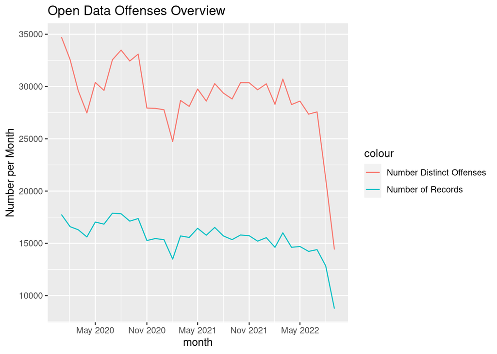

Recent Offenses

|  | month | Total Records | Total Distinct Offenses |
| --- | --- | --- | --- |
| 28 | 2022-04-01 | 14620 | 28274 |
| 29 | 2022-05-01 | 14698 | 28607 |
| 30 | 2022-06-01 | 14229 | 27357 |
| 31 | 2022-07-01 | 14399 | 27572 |
| 32 | 2022-08-01 | 12840 | 21175 |
| 33 | 2022-09-01 | 8750 | 14405 |

There is a shape decline in the last month. We will ignore that month, assuming that it is due to a lag in reporting and assimilating.

## Outlier Overview

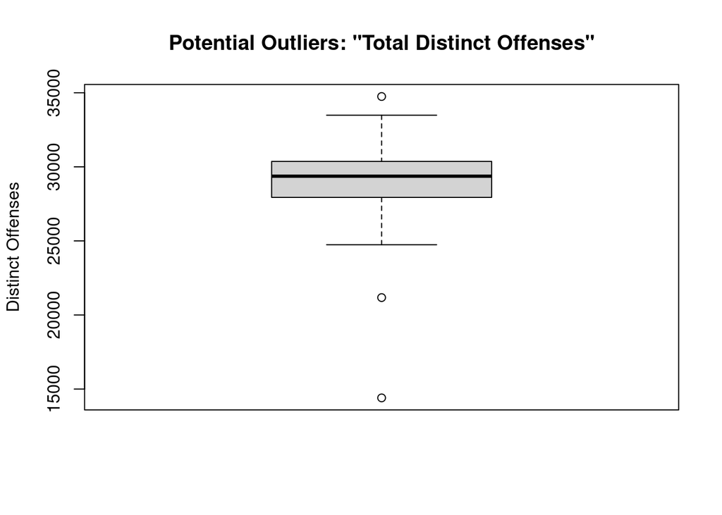

Potential Outliers: “Total Distinct Offenses”

|  | month | Total Records | Total Distinct Offenses | z_score |
| --- | --- | --- | --- | --- |
| 1 | 2020-01-01 | 17760 | 34747 | 1.59 |
| 32 | 2022-08-01 | 12840 | 21175 | -2.13 |
| 33 | 2022-09-01 | 8750 | 14405 | -3.98 |

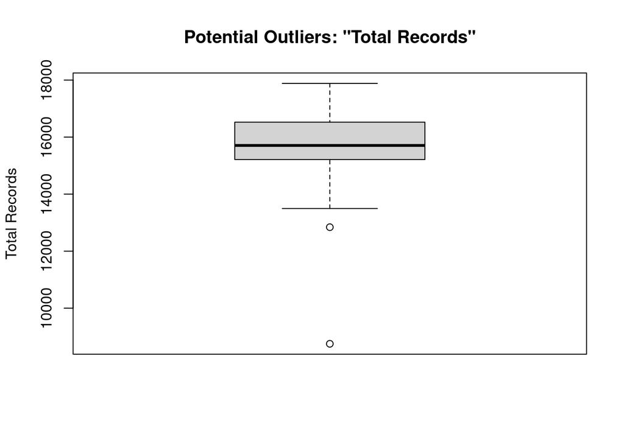

Potential Outliers: “Total Records”

|  | month | Total Records | Total Distinct Offenses | z_score |
| --- | --- | --- | --- | --- |
| 32 | 2022-08-01 | 12840 | 21175 | -1.6 |
| 33 | 2022-09-01 | 8750 | 14405 | -4.0 |

We will then be excluding month 33, ‘2022-09-01’.

# Population

For per ca-pita calculations we need to know the population broken down by counties. This data is in the Census data set. The data gives us the population in 2010 and 2020 along with the percentage change.

County Population

| county | 2010 | 2020 | percent_change | pop_rate_year |
| --- | --- | --- | --- | --- |
| baker | 16134 | 16668 | 0.0330978 | 0.0033098 |
| clackamas | 375992 | 421401 | 0.1207712 | 0.0120771 |
| lane | 351715 | 382971 | 0.0888674 | 0.0088867 |
| multnomah | 735334 | 815428 | 0.1089219 | 0.0108922 |
| washington | 529710 | 600372 | 0.1333975 | 0.0133398 |

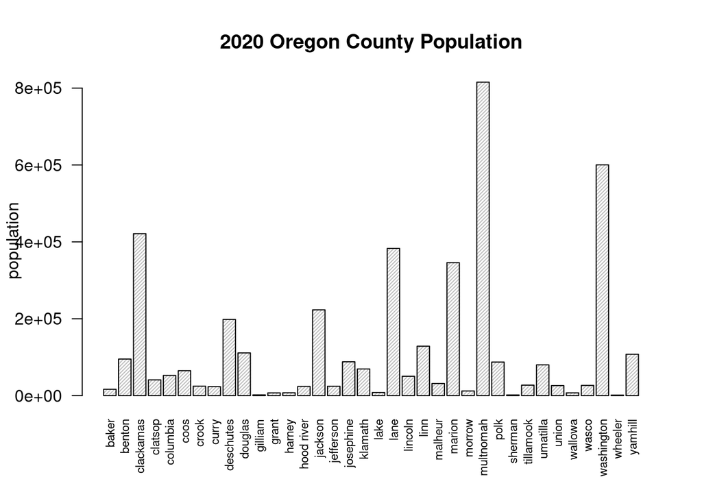

# Violent Offenses

Violent offenses are of particular concern so let’s look at those offenses. To determine which offenses are violent we use the FBI’s definition of violent crimes to categorize the ‘NIBRS Report Title’ column in the data set.

Violent Offense Titles

| x |
| --- |
| Aggravated Assault |
| Forcible Rape |
| Forcible Sodomy |
| Robbery |
| Willful Murder |

We can look at the break down of these violent offenses for the whole state.

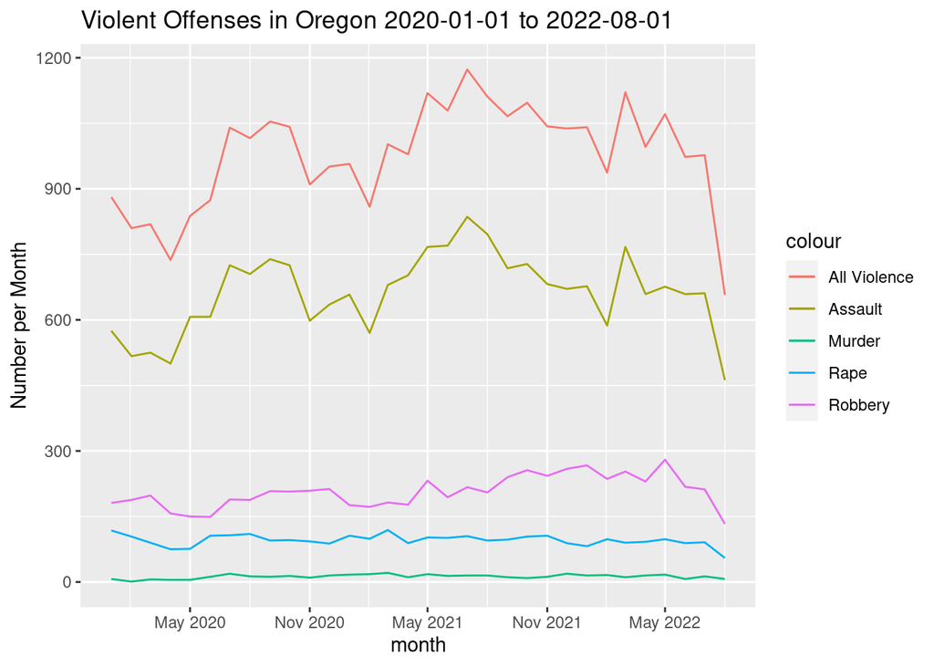

Monthly Violent Offenses 2020-01-01 to 2022-08-01

|  | month | Aggravated Assault | Forcible Rape | Robbery | Willful Murder | All Violent Offenses | Nonviolent Offenses |
| --- | --- | --- | --- | --- | --- | --- | --- |
| 27 | 2022-03-01 | 767 | 90 | 253 | 11 | 1121 | 29591 |
| 28 | 2022-04-01 | 659 | 92 | 230 | 15 | 996 | 27278 |
| 29 | 2022-05-01 | 676 | 98 | 280 | 17 | 1071 | 27536 |
| 30 | 2022-06-01 | 659 | 89 | 218 | 7 | 973 | 26384 |
| 31 | 2022-07-01 | 661 | 91 | 212 | 13 | 977 | 26595 |
| 32 | 2022-08-01 | 462 | 55 | 133 | 7 | 657 | 20518 |

We can also compare the number of violent offenses verses non-violent offenses for the state over the study period.

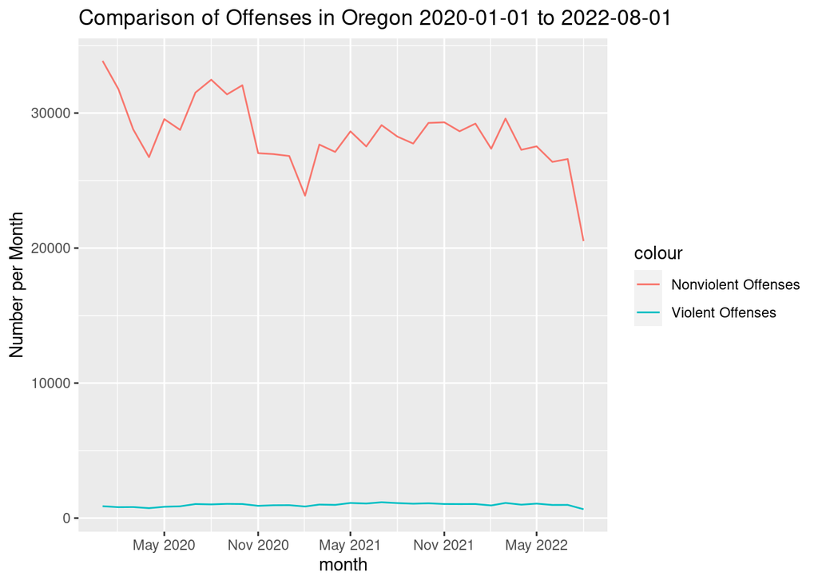

Next we can look at the total number of distinct violent offenses by county.

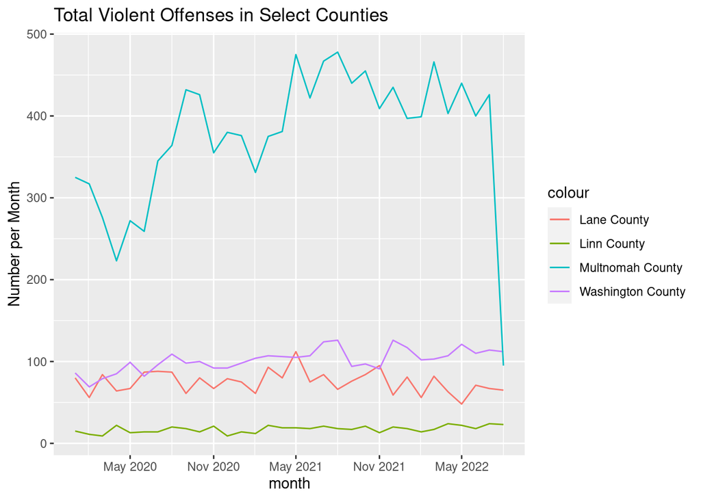

# Violent Offenses by County

We can look at the aggregates of violent offenses by county.

County Total Violent Offenses

| county | offenses | vo_percap |
| --- | --- | --- |
| oregon | 31268 | 0.74 |
| baker | 79 | 0.47 |
| benton | 382 | 0.40 |
| clackamas | 1908 | 0.45 |
| clatsop | 350 | 0.85 |
| columbia | 228 | 0.43 |
| coos | 294 | 0.45 |
| crook | 148 | 0.60 |
| curry | 105 | 0.45 |
| deschutes | 841 | 0.42 |
| douglas | 728 | 0.65 |
| gilliam | 10 | 0.50 |
| grant | 6 | 0.08 |
| harney | 20 | 0.27 |
| hood river | 61 | 0.25 |
| jackson | 1356 | 0.61 |
| jefferson | 52 | 0.21 |
| josephine | 695 | 0.79 |
| klamath | 626 | 0.90 |
| lake | 58 | 0.71 |
| lane | 2393 | 0.62 |
| lincoln | 359 | 0.71 |
| linn | 554 | 0.43 |
| malheur | 200 | 0.63 |
| marion | 2815 | 0.81 |
| morrow | 78 | 0.64 |
| multnomah | 12044 | 1.48 |
| polk | 307 | 0.35 |
| sherman | 11 | 0.59 |
| tillamook | 138 | 0.50 |
| umatilla | 434 | 0.54 |
| union | 107 | 0.41 |
| wallowa | 2 | 0.03 |
| wasco | 197 | 0.74 |
| washington | 3258 | 0.54 |
| wheeler | 0 | 0.00 |
| yamhill | 424 | 0.39 |

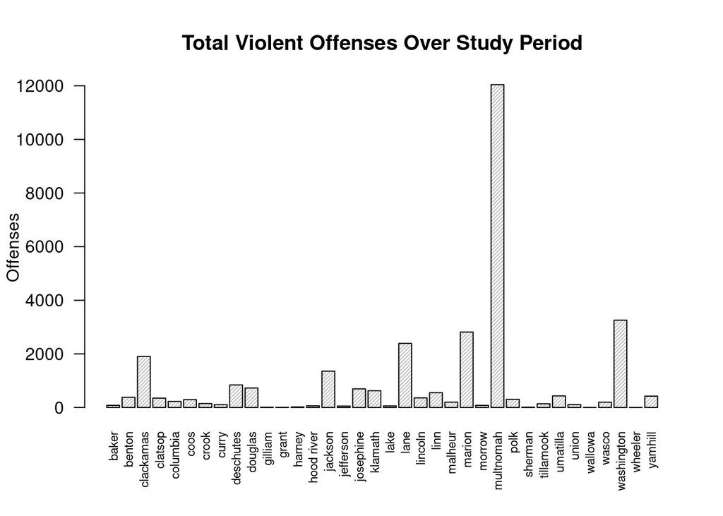

From the table it appears that the rate of violent offenses is far higher in Multnomah county than others.

Counties with Highest Per Capita Violent Offenses

|  | county | offenses | 2020 | vo_percap |
| --- | --- | --- | --- | --- |
| 26 | multnomah | 12044 | 815428 | 1.48 |
| 18 | klamath | 626 | 69413 | 0.90 |
| 4 | clatsop | 350 | 41072 | 0.85 |
| 24 | marion | 2815 | 345920 | 0.81 |
| 17 | josephine | 695 | 88090 | 0.79 |
| 34 | wasco | 197 | 26670 | 0.74 |
| 27 | oregon | 31268 | 4237256 | 0.74 |
| 21 | lincoln | 359 | 50395 | 0.71 |
| 19 | lake | 58 | 8160 | 0.71 |
| 10 | douglas | 728 | 111201 | 0.65 |
| 25 | morrow | 78 | 12186 | 0.64 |
| 23 | malheur | 200 | 31571 | 0.63 |
| 20 | lane | 2393 | 382971 | 0.62 |
| 15 | jackson | 1356 | 223259 | 0.61 |
| 7 | crook | 148 | 24738 | 0.60 |
| 29 | sherman | 11 | 1870 | 0.59 |
| 35 | washington | 3258 | 600372 | 0.54 |
| 31 | umatilla | 434 | 80075 | 0.54 |
| 30 | tillamook | 138 | 27390 | 0.50 |
| 11 | gilliam | 10 | 1995 | 0.50 |
| 1 | baker | 79 | 16668 | 0.47 |
| 6 | coos | 294 | 64929 | 0.45 |
| 3 | clackamas | 1908 | 421401 | 0.45 |
| 8 | curry | 105 | 23446 | 0.45 |
| 5 | columbia | 228 | 52589 | 0.43 |
| 22 | linn | 554 | 128610 | 0.43 |
| 9 | deschutes | 841 | 198253 | 0.42 |
| 32 | union | 107 | 26196 | 0.41 |
| 2 | benton | 382 | 95184 | 0.40 |
| 37 | yamhill | 424 | 107722 | 0.39 |
| 28 | polk | 307 | 87433 | 0.35 |
| 13 | harney | 20 | 7495 | 0.27 |
| 14 | hood river | 61 | 23977 | 0.25 |
| 16 | jefferson | 52 | 24502 | 0.21 |
| 12 | grant | 6 | 7233 | 0.08 |
| 33 | wallowa | 2 | 7391 | 0.03 |
| 36 | wheeler | 0 | 1451 | 0.00 |

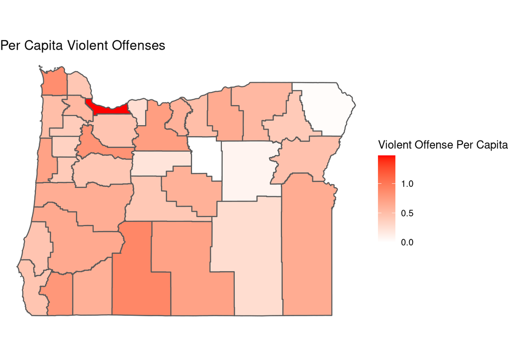

# Corrlation

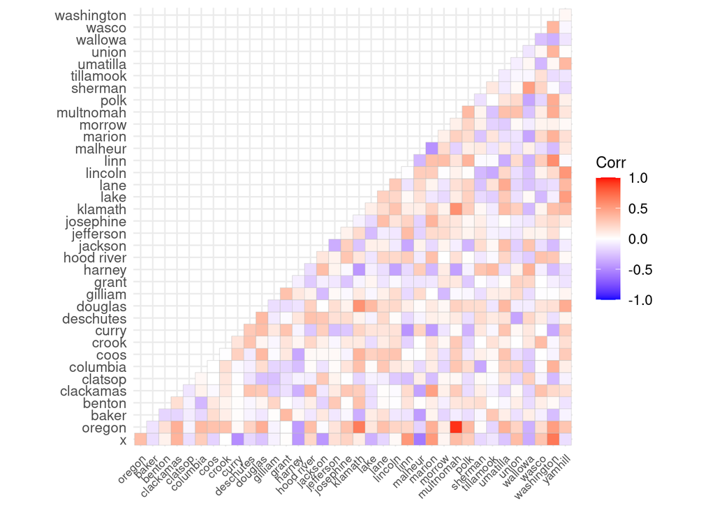

### Total monthly violent offenses by county

Counties with positiv correlation >0.32

|  | pearson_cor |
| --- | --- |
| x | 1.00 |
| oregon | 0.34 |
| clackamas | 0.39 |
| linn | 0.53 |
| marion | 0.52 |
| multnomah | 0.35 |
| union | 0.35 |
| washington | 0.68 |

Counties with negative correlation < -0.32

|  | pearson_cor |
| --- | --- |
| curry | -0.49 |
| harney | -0.45 |
| jackson | -0.45 |
| lake | -0.34 |
| malheur | -0.58 |
| wallowa | -0.36 |

# Linear Regression

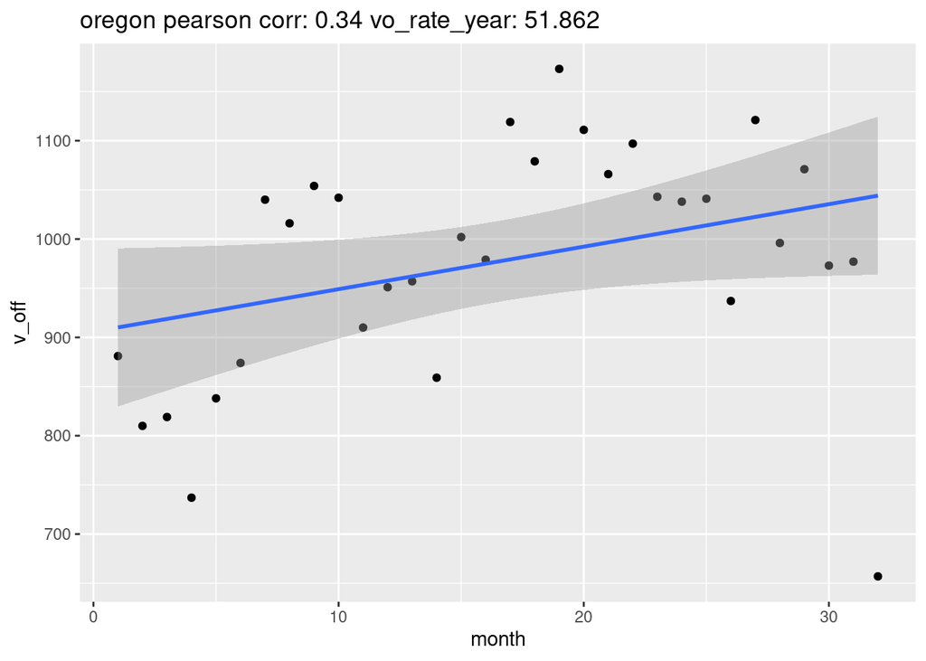

pearson correlation and linear reg rate

|  | county | pearson_cor | 2020 | vo_rate_year | pop_rate_year | adjusted_rate |
| --- | --- | --- | --- | --- | --- | --- |
| 37 | x | 1.00 | NA | NA | NA | NA |
| 35 | washington | 0.68 | 600372 | 11.86 | 0.01 | 11.85 |
| 22 | linn | 0.53 | 128610 | 2.86 | 0.01 | 2.85 |
| 24 | marion | 0.52 | 345920 | 8.62 | 0.01 | 8.61 |
| 3 | clackamas | 0.39 | 421401 | 5.53 | 0.01 | 5.52 |
| 26 | multnomah | 0.35 | 815428 | 37.05 | 0.01 | 37.04 |

pearson correlation and linear reg rate

|  | county | pearson_cor | 2020 | vo_rate_year | pop_rate_year | adjusted_rate |
| --- | --- | --- | --- | --- | --- | --- |
| 33 | wallowa | -0.36 | 7391 | -0.11 | 0.01 | -0.12 |
| 13 | harney | -0.45 | 7495 | -0.52 | 0.00 | -0.52 |
| 15 | jackson | -0.45 | 223259 | -5.19 | 0.01 | -5.20 |
| 8 | curry | -0.49 | 23446 | -1.69 | 0.00 | -1.69 |
| 23 | malheur | -0.58 | 31571 | -3.02 | 0.00 | -3.02 |
| 36 | wheeler | NA | 1451 | 0.00 | 0.00 | 0.00 |

# Sources

#### Oregon Crime Data

“Oregon State Police: Uniform Crime Reporting”

```
https://www.oregon.gov/osp/Pages/Uniform-Crime-Reporting-Data.aspx
```

#### Oregon Census Data

“Census Data for Oregon” Population Research Center

```
https://www.pdx.edu/population-research/census-data-oregon
```

Direct link for data set:

```
https://drive.google.com/uc?export=download&id=1JrrmYiQUBPux8nnJ88epAAk9U5rbRDBD
```

##### FBI

“FBI-Violent Crime” FBI: UCR

```
https://ucr.fbi.gov/crime-in-the-u.s/2019/crime-in-the-u.s.-2019/topic-pages/violent-crime
```

#### Oregon Spatial Data Library

“Oregon Counties - 2015”

```
https://spatialdata.oregonexplorer.info/geoportal/details;id=361c06fee9de4e24a72e280fb386a771
```

# APPENDIX A

Appendix description: Raw data tables.

# A1 Total Violent Offenses Per Capita per County

Total counts for study period:

County Total Violent Offenses

| county | offenses | vo_percap |
| --- | --- | --- |
| oregon | 31268 | 0.7379304 |
| baker | 79 | 0.4739621 |
| benton | 382 | 0.4013280 |
| clackamas | 1908 | 0.4527754 |
| clatsop | 350 | 0.8521621 |
| columbia | 228 | 0.4335507 |
| coos | 294 | 0.4528023 |
| crook | 148 | 0.5982699 |
| curry | 105 | 0.4478376 |
| deschutes | 841 | 0.4242054 |
| douglas | 728 | 0.6546704 |
| gilliam | 10 | 0.5012531 |
| grant | 6 | 0.0829531 |
| harney | 20 | 0.2668446 |
| hood river | 61 | 0.2544105 |
| jackson | 1356 | 0.6073663 |
| jefferson | 52 | 0.2122276 |
| josephine | 695 | 0.7889658 |
| klamath | 626 | 0.9018484 |
| lake | 58 | 0.7107843 |
| lane | 2393 | 0.6248515 |
| lincoln | 359 | 0.7123723 |
| linn | 554 | 0.4307597 |
| malheur | 200 | 0.6334928 |
| marion | 2815 | 0.8137720 |
| morrow | 78 | 0.6400788 |
| multnomah | 12044 | 1.4770158 |
| polk | 307 | 0.3511260 |
| sherman | 11 | 0.5882353 |
| tillamook | 138 | 0.5038335 |
| umatilla | 434 | 0.5419919 |
| union | 107 | 0.4084593 |
| wallowa | 2 | 0.0270599 |
| wasco | 197 | 0.7386577 |
| washington | 3258 | 0.5426635 |
| wheeler | 0 | 0.0000000 |
| yamhill | 424 | 0.3936058 |

# A2 Population

County Population 2010 and 2020

| county | 2010 | 2020 | percent_change |
| --- | --- | --- | --- |
| oregon | 3831074 | 4237256 | 0.1060230 |
| baker | 16134 | 16668 | 0.0330978 |
| benton | 85579 | 95184 | 0.1122355 |
| clackamas | 375992 | 421401 | 0.1207712 |
| clatsop | 37039 | 41072 | 0.1088852 |
| columbia | 49351 | 52589 | 0.0656116 |
| coos | 63043 | 64929 | 0.0299161 |
| crook | 20978 | 24738 | 0.1792354 |
| curry | 22364 | 23446 | 0.0483813 |
| deschutes | 157733 | 198253 | 0.2568898 |
| douglas | 107667 | 111201 | 0.0328234 |
| gilliam | 1871 | 1995 | 0.0662747 |
| grant | 7445 | 7233 | -0.0284755 |
| harney | 7422 | 7495 | 0.0098356 |
| hood river | 22346 | 23977 | 0.0729885 |
| jackson | 203206 | 223259 | 0.0986831 |
| jefferson | 21720 | 24502 | 0.1280847 |
| josephine | 82713 | 88090 | 0.0650079 |
| klamath | 66380 | 69413 | 0.0456915 |
| lake | 7895 | 8160 | 0.0335655 |
| lane | 351715 | 382971 | 0.0888674 |
| lincoln | 46034 | 50395 | 0.0947343 |
| linn | 116672 | 128610 | 0.1023210 |
| malheur | 31313 | 31571 | 0.0082394 |
| marion | 315335 | 345920 | 0.0969921 |
| morrow | 11173 | 12186 | 0.0906650 |
| multnomah | 735334 | 815428 | 0.1089219 |
| polk | 75403 | 87433 | 0.1595427 |
| sherman | 1765 | 1870 | 0.0594901 |
| tillamook | 25250 | 27390 | 0.0847525 |
| umatilla | 75889 | 80075 | 0.0551595 |
| union | 25748 | 26196 | 0.0173994 |
| wallowa | 7008 | 7391 | 0.0546518 |
| wasco | 25213 | 26670 | 0.0577876 |
| washington | 529710 | 600372 | 0.1333975 |
| wheeler | 1441 | 1451 | 0.0069396 |
| yamhill | 99193 | 107722 | 0.0859839 |

# A4 Sums of offenses by type by date

Aggregate Monthly Counts

| month | Total Records | Total Distinct Offenses | Part 3 | Traffic Crime | Simple Assault | Fraud Offenses | Larceny/Theft Offenses | Motor Vehicle Theft | Robbery | Vandalism | All Other Offenses | Disorderly Conduct |
| --- | --- | --- | --- | --- | --- | --- | --- | --- | --- | --- | --- | --- |
| 2020-01-01 | 17760 | 34747 | 4263 | 1447 | 1704 | 1690 | 7636 | 1299 | 181 | 3032 | 5207 | 967 |
| 2020-02-01 | 16598 | 32584 | 4113 | 1409 | 1609 | 1601 | 6980 | 1118 | 188 | 2814 | 4870 | 945 |
| 2020-03-01 | 16301 | 29613 | 3274 | 1163 | 1565 | 1422 | 6328 | 1193 | 198 | 2897 | 4354 | 903 |
| 2020-04-01 | 15612 | 27472 | 2518 | 1128 | 1473 | 1498 | 6202 | 1307 | 157 | 2924 | 3661 | 812 |
| 2020-05-01 | 17036 | 30390 | 2766 | 1381 | 1667 | 1416 | 6294 | 1154 | 150 | 3253 | 4227 | 1081 |
| 2020-06-01 | 16836 | 29629 | 3118 | 1382 | 1690 | 1459 | 6335 | 1170 | 149 | 3324 | 3614 | 1120 |

# A5 Correlation Matrix of Total Monthly Violent Offenses

pearson correlation and linear reg rate

| county | pearson_cor | 2020 | vo_rate_year | pop_rate_year | adjusted_rate |
| --- | --- | --- | --- | --- | --- |
| baker | -0.136 | 16668 | -0.284 | 0.0033098 | -0.287 |
| benton | 0.069 | 95184 | 0.383 | 0.0112235 | 0.372 |
| clackamas | 0.388 | 421401 | 5.534 | 0.0120771 | 5.522 |
| clatsop | -0.141 | 41072 | -0.871 | 0.0108885 | -0.882 |
| columbia | 0.263 | 52589 | 1.157 | 0.0065612 | 1.150 |
| coos | -0.192 | 64929 | -0.638 | 0.0029916 | -0.641 |
| crook | 0.000 | 24738 | 0.000 | 0.0179235 | -0.018 |
| curry | -0.488 | 23446 | -1.687 | 0.0048381 | -1.692 |
| deschutes | -0.170 | 198253 | -1.304 | 0.0256890 | -1.330 |
| douglas | -0.252 | 111201 | -1.786 | 0.0032823 | -1.789 |
| gilliam | -0.064 | 1995 | -0.044 | 0.0066275 | -0.051 |
| grant | 0.009 | 7233 | 0.004 | -0.0028475 | 0.007 |
| harney | -0.447 | 7495 | -0.519 | 0.0009836 | -0.520 |
| hood river | 0.207 | 23977 | 0.438 | 0.0072988 | 0.431 |
| jackson | -0.453 | 223259 | -5.186 | 0.0098683 | -5.196 |
| jefferson | 0.156 | 24502 | 0.282 | 0.0128085 | 0.269 |
| josephine | 0.232 | 88090 | 1.880 | 0.0065008 | 1.873 |
| klamath | 0.097 | 69413 | 0.946 | 0.0045691 | 0.941 |
| lake | -0.341 | 8160 | -0.739 | 0.0033566 | -0.742 |
| lane | -0.183 | 382971 | -3.187 | 0.0088867 | -3.196 |
| lincoln | 0.026 | 50395 | 0.121 | 0.0094734 | 0.112 |
| linn | 0.528 | 128610 | 2.859 | 0.0102321 | 2.849 |
| malheur | -0.584 | 31571 | -3.018 | 0.0008239 | -3.019 |
| marion | 0.525 | 345920 | 8.615 | 0.0096992 | 8.605 |
| morrow | 0.050 | 12186 | 0.097 | 0.0090665 | 0.088 |
| multnomah | 0.348 | 815428 | 37.047 | 0.0108922 | 37.036 |
| oregon | 0.340 | 4237256 | 51.862 | 0.0106023 | 51.851 |
| polk | 0.265 | 87433 | 0.922 | 0.0159543 | 0.906 |
| sherman | -0.174 | 1870 | -0.134 | 0.0059490 | -0.140 |
| tillamook | -0.110 | 27390 | -0.286 | 0.0084752 | -0.294 |
| umatilla | -0.252 | 80075 | -1.883 | 0.0055160 | -1.889 |
| union | 0.348 | 26196 | 0.922 | 0.0017399 | 0.920 |
| wallowa | -0.364 | 7391 | -0.114 | 0.0054652 | -0.119 |
| wasco | 0.310 | 26670 | 1.212 | 0.0057788 | 1.206 |
| washington | 0.682 | 600372 | 11.864 | 0.0133398 | 11.851 |
| wheeler | NA | 1451 | 0.000 | 0.0006940 | -0.001 |
| x | 1.000 | NA | NA | NA | NA |
| yamhill | -0.136 | 107722 | -0.739 | 0.0085984 | -0.748 |

# A6 Violent offenses per county

[output not shown]

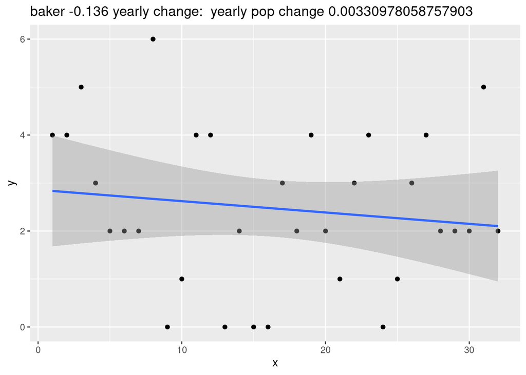

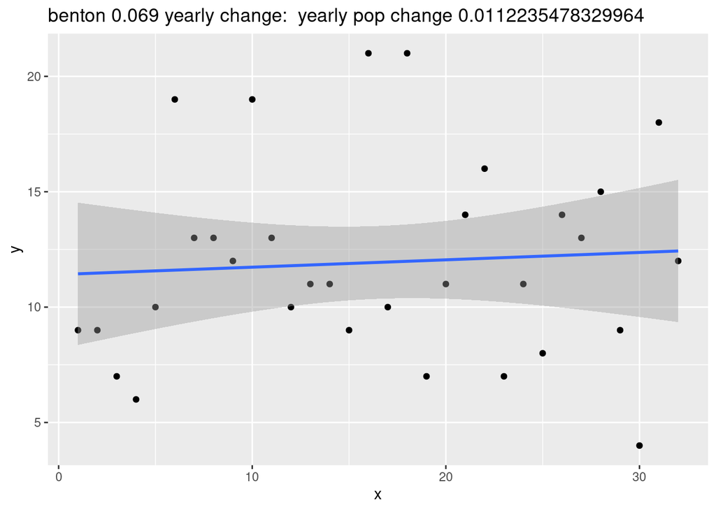

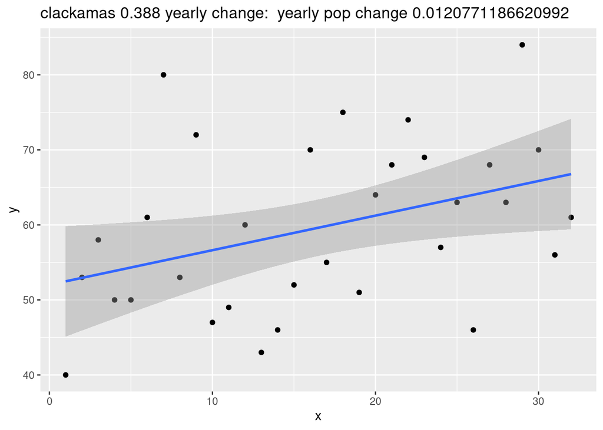

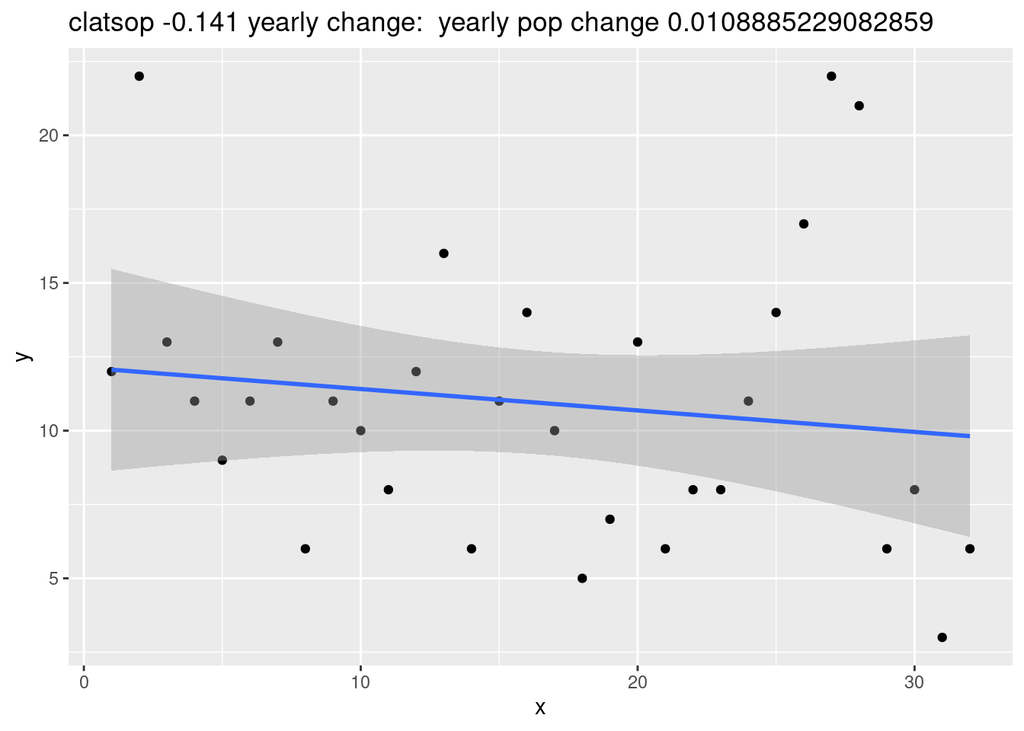

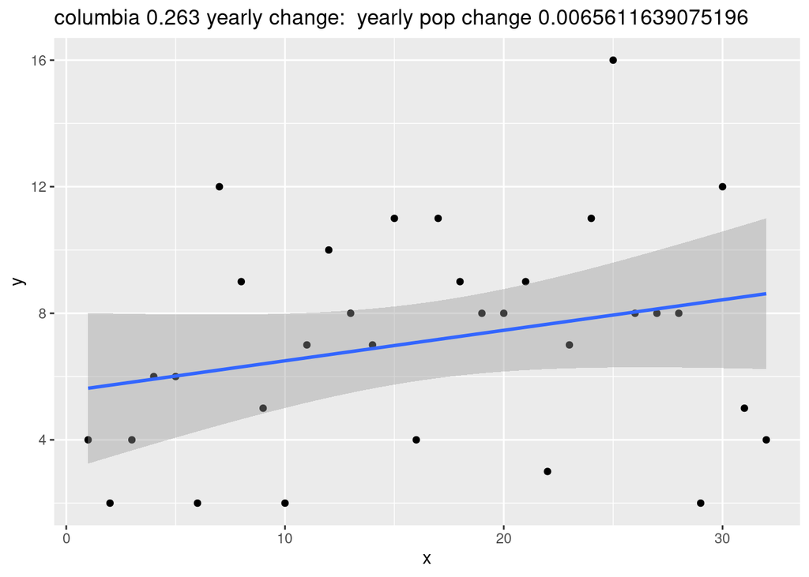

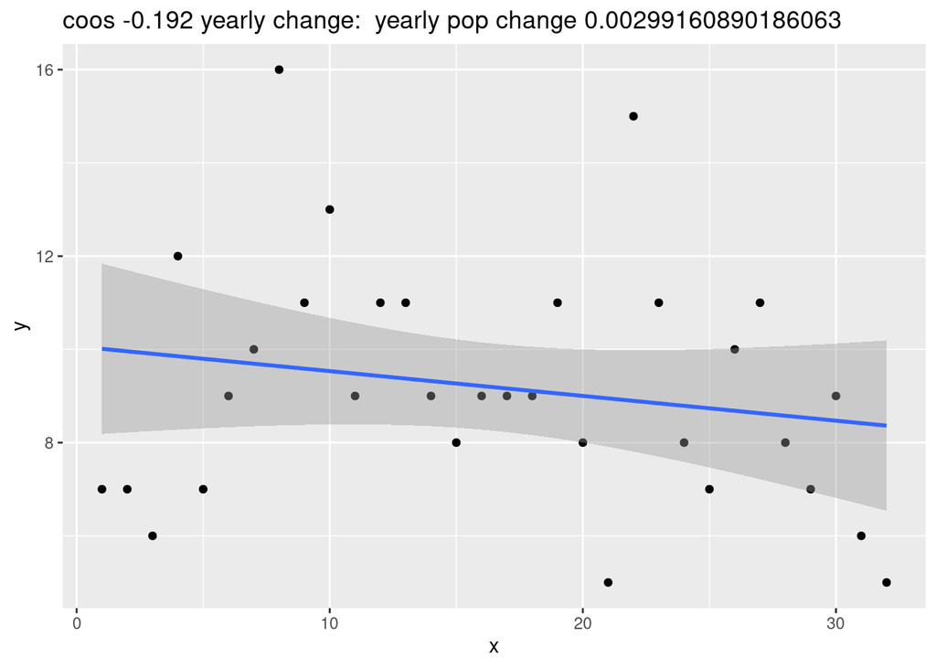

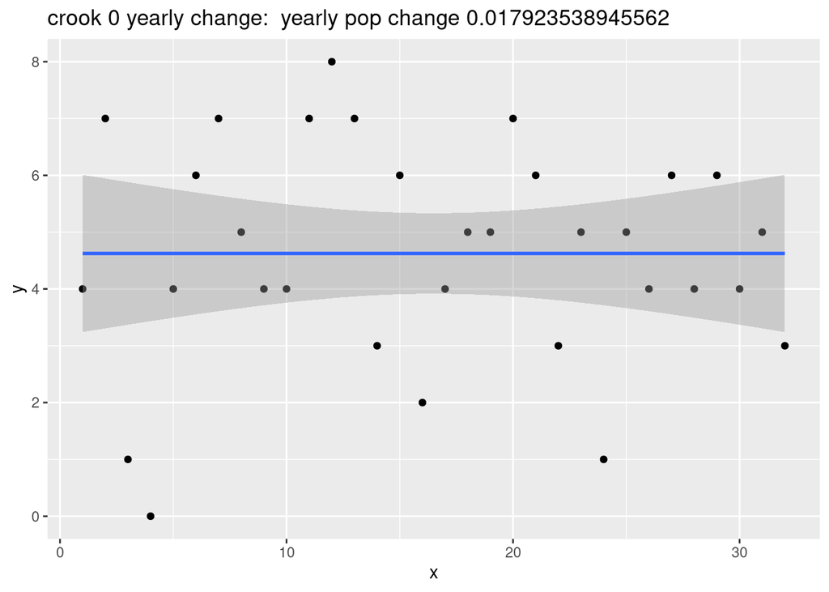

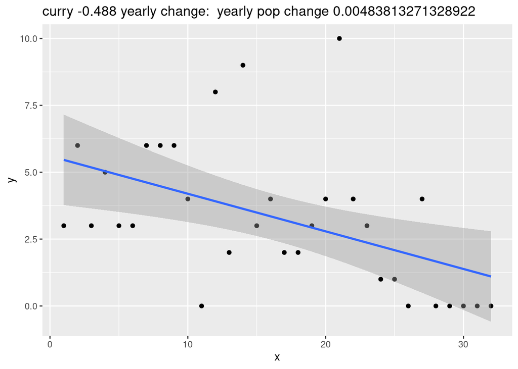

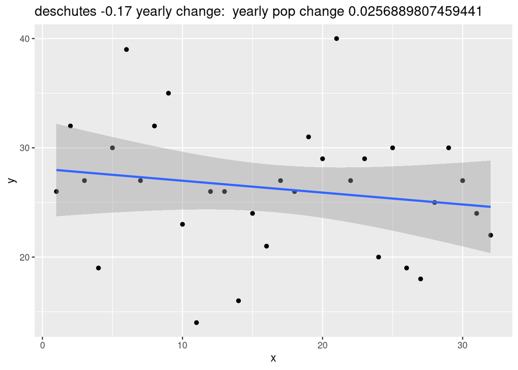

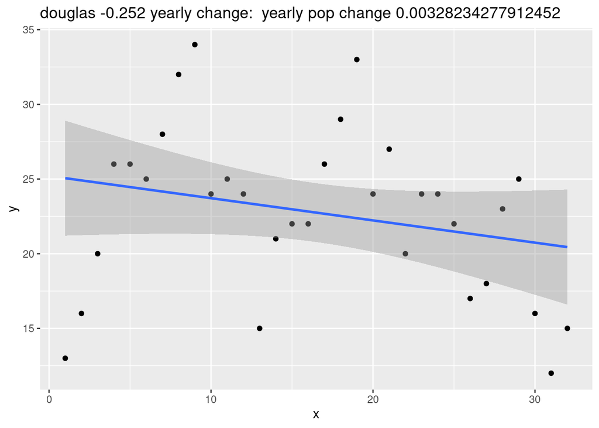

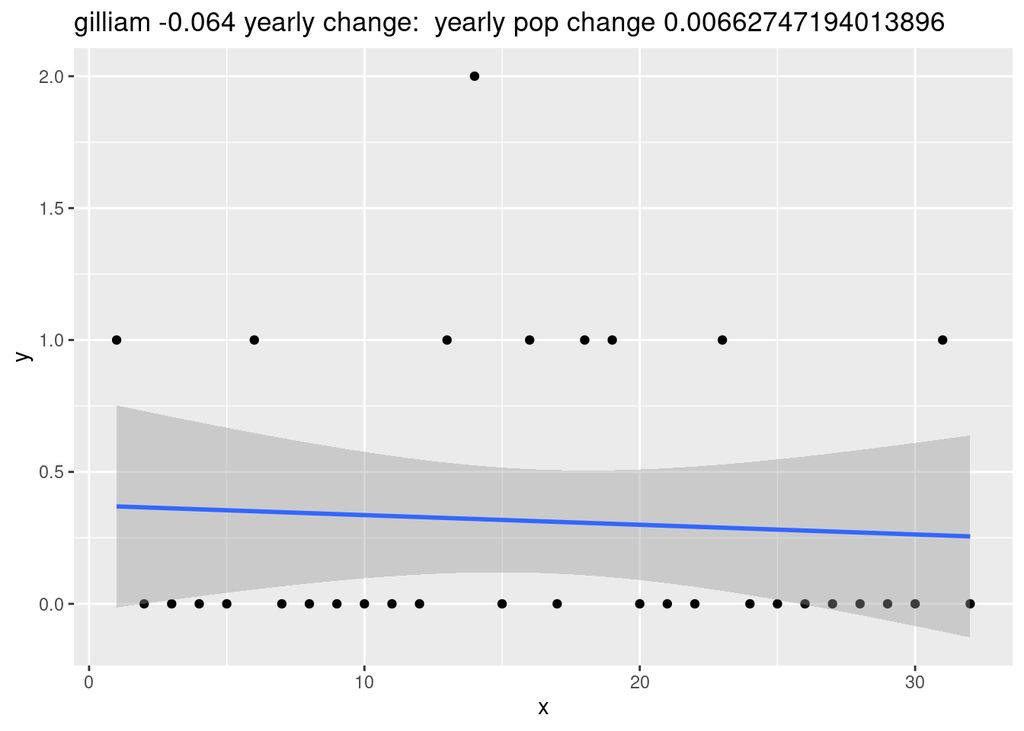

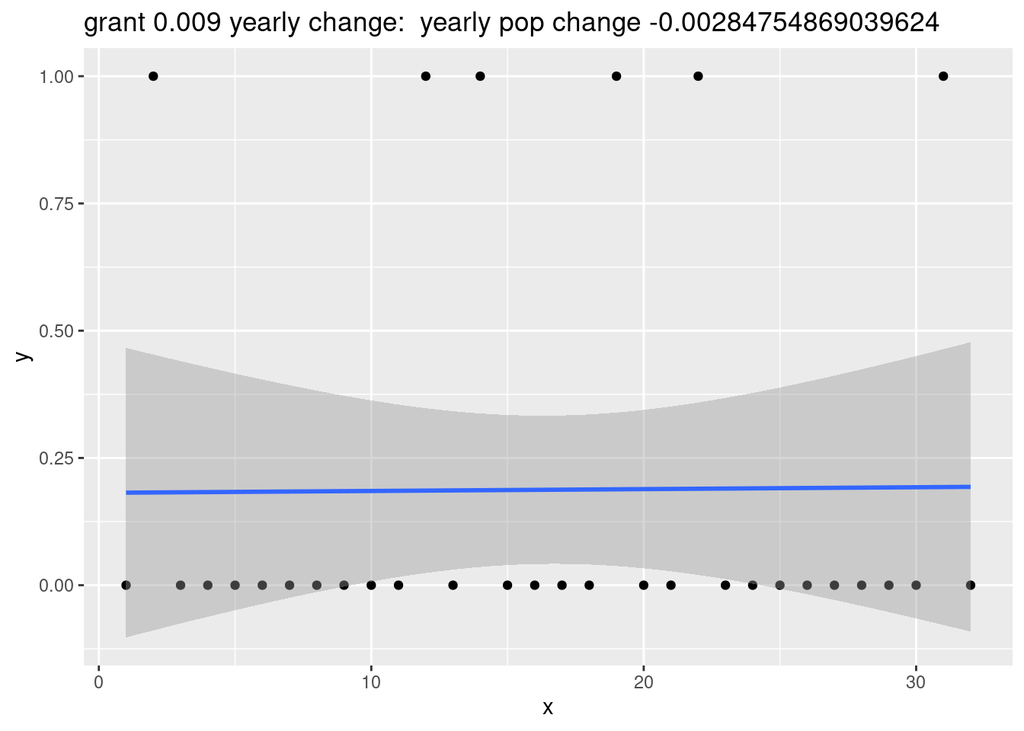

[24 more figures not shown]

# Appendix B

source code available at https://github.com/russl-corey/Oregon_Crime

This program is free software: you can redistribute it and/or modify it under the terms of the GNU General Public License as published by the Free Software Foundation, either version 3 of the License, or (at your option) any later version.

This program is distributed in the hope that it will be useful, but WITHOUT ANY WARRANTY; without even the implied warranty of MERCHANTABILITY or FITNESS FOR A PARTICULAR PURPOSE. See the GNU General Public License for more details. You should have received a copy of the GNU General Public License along with this program. If not, see [<https://www.gnu.org/licenses/>](https://www.gnu.org/licenses/).